# Classification and Clustering

**Disclaimer:** *Some of content of this notebook has been modified by, guided by, optimized by, and/or generated using GPT3.5 & GPT4.*

K-means and K-Nearest Neighbors (KNN) are two popular machine learning algorithms used for clustering and classification tasks respectively. Here's a summary:

1. K-means:

   Type: Unsupervised learning algorithm

   Purpose: Clustering

   Procedure: K-means aims to partition a dataset into K clusters, where each data point belongs to the cluster with the nearest mean. The algorithm consists of the following steps:
   - (a) Initialize K cluster centroids randomly.
   - (b) Assign each data point to the nearest centroid.
   - (c) Update the centroids by calculating the mean of all data points assigned to each centroid.
   - (d) Repeat steps b and c until the centroids' positions become stable or a predetermined number of iterations are reached.
1. K-Nearest Neighbors (KNN):

   Type: Supervised learning algorithm

   Purpose: Classification (and regression)

   Procedure: KNN classifies a new data point based on the majority class of its K nearest neighbors in the training dataset. The steps are:
   - (a) Choose the number of neighbors K.
   - (b) Calculate the Euclidean distance between the new data point and all the training data points.
   - (c) Identify the K nearest neighbors to the new data point.
   - (d) Determine the majority class among these K neighbors and assign it to the new data point.

Both algorithms rely on the choice of K, which can significantly affect their performance. Choosing an optimal K is typically done through cross-validation or other model evaluation techniques.

Import nessessary packages mainly NumPy and Pandas.

```python
import numpy as np
import pandas as pd
import matplotlib.pyplot as plt

# For recursive Linux-like file loading
import glob
import time
```

Import the relevant training and test data for the assignment by moving giving the working directory path of the data for both K-Means and KNN. Using list comprehension we can create a list of all the dataframes that can be accessed in their appropriate method calls.

```python
files =  glob.glob("/content/drive/MyDrive/Computer Science/CSCI436/Homework/Assignment-2/**/*/*.csv",
                   recursive = True)

dfs = [pd.read_csv(file) for file in files]
```

## K-Means

Below is the implementation of K-Means++ with the option for PCA. Data fed into this model is automatically standardized for better classification

```python
def pca(X, num_components):
    # Standardize the data
    X_scaled = (X - X.mean(axis=0)) / X.std(axis=0)

    # Compute covariance matrix
    cov_matrix = np.cov(X_scaled.T)

    # Compute eigenvectors and eigenvalues
    eigenvalues, eigenvectors = np.linalg.eig(cov_matrix)

    # Sort eigenvectors by eigenvalues in descending order
    sorted_indices = np.argsort(eigenvalues)[::-1]
    sorted_eigenvectors = eigenvectors[:,sorted_indices]

    # Select the top num_components eigenvectors
    principal_components = sorted_eigenvectors[:,:num_components]

    # Transform the data to the new coordinate system
    transformed_data = np.dot(X_scaled, principal_components)

    return transformed_data


class KMeans:

    def __init__(self, k=3, num_iters=100, pca_components=None):
        self.k = k
        self.num_iters = num_iters
        self.pca_components = pca_components

    def fit(self, X):
        if self.pca_components is not None:
            # Apply PCA to reduce the dimensionality of the data
            X = pca(X, self.pca_components)

        # Standardize the data
        X_scaled = (X - X.mean(axis=0)) / X.std(axis=0)

        # Initialize centroids using k-means++ initialization
        self.centroids = [X_scaled[np.random.choice(X_scaled.shape[0])]]
        for i in range(1, self.k):
            distances = np.sqrt(((X_scaled - self.centroids[-1])**2).sum(axis=1))
            probabilities = distances ** 2 / np.sum(distances ** 2)
            new_centroid = X_scaled[np.random.choice(X_scaled.shape[0], p=probabilities)]
            self.centroids.append(new_centroid)
        self.centroids = np.array(self.centroids)

        for i in range(self.num_iters):
            # Assign each point to the closest centroid
            distances = np.sqrt(((X_scaled - self.centroids[:, np.newaxis])**2).sum(axis=2))
            self.labels = np.argmin(distances, axis=0)

            # Update the centroids to the mean of the points in each cluster
            new_centroids = np.array([X_scaled[self.labels == j].mean(axis=0) for j in range(self.k)])

            # Check for convergence
            if np.allclose(self.centroids, new_centroids):
                break

            self.centroids = new_centroids

        # Compute the silhouette score for the final clustering
        self.score = silhouette_score(X_scaled, self.labels)


    def predict(self, X):
        if self.pca_components is not None:
            # Apply PCA to reduce the dimensionality of the data
            X = pca(X, self.pca_components)

        # Standardize the data
        X_scaled = (X - X.mean(axis=0)) / X.std(axis=0)

        distances = np.sqrt(((X_scaled - self.centroids[:, np.newaxis])**2).sum(axis=2))
        return np.argmin(distances, axis=0)

    def plot_clusters(self, X):
        if self.pca_components is not None:
            # Apply PCA to reduce the dimensionality of the data
            X = pca(X, self.pca_components)

        # Standardize the data
        X_scaled = (X - X.mean(axis=0)) / X.std(axis=0)

        plt.figure(figsize=(12, 8))
        for cluster_id in range(self.k):
            plt.scatter(X_scaled[self.labels == cluster_id, 0], X_scaled[self.labels == cluster_id, 1], label=f"Cluster {cluster_id}")
        plt.scatter(self.centroids[:, 0], self.centroids[:, 1], marker='x', c='red', s=100, label='Centroids')
        plt.xlabel("Feature 1")
        plt.ylabel("Feature 2")
        plt.legend()
        plt.title("KMeans Clustering")
        plt.show()

def silhouette_score(X, labels):
    # Compute pairwise distances between data points
    distances = np.sqrt(((X[:, np.newaxis, :] - X)**2).sum(axis=2))

    # Compute the mean distance from each data point to all other points in its cluster
    cluster_distances = np.zeros_like(distances)
    for i in range(len(X)):
        cluster_mask = (labels == labels[i])
        cluster_distances[i, cluster_mask] = np.mean(distances[i, cluster_mask])

    # Compute the mean distance from each data point to all other points in the nearest cluster
    nearest_cluster_distances = np.zeros_like(distances)
    for i in range(len(X)):
        other_clusters_mask = (labels != labels[i])
        nearest_cluster_distances[i, other_clusters_mask] = np.min(distances[i, other_clusters_mask])

    # Compute the silhouette score for each data point
    silhouette_scores = (nearest_cluster_distances - cluster_distances) / np.maximum(nearest_cluster_distances, cluster_distances)

    # Take the mean of the silhouette scores as the overall score
    return np.mean(silhouette_scores)
```

```python
def prepare_data(kmeans_train, kmeans_valid, kmeans_test):
    # Prepares the data for KMeans by concatenating the training and validation sets and extracting the test set.
    X_train = pd.concat([kmeans_train.iloc[:, 1:5], kmeans_valid.iloc[:, 1:5]])
    X_test = kmeans_test.iloc[:, 1:5]
    X_valid = kmeans_valid.iloc[:, 1:5]
    return X_train, X_test, X_valid

def fit_and_evaluate_kmeans(X_train, X_valid, kmeans_valid):
    # Fits the KMeans model and evaluates it using the validation set.
    label_titles = {0: 'cluster_x', 1: 'cluster_y', 2: 'cluster_z'}
    kmeans = KMeans(k=3, pca_components=3)

    X_train_values = X_train.values
    X_valid_values = X_valid.values

    kmeans.fit(X_train_values)
    print(f"The training Silhouette Score is: {kmeans.score}")

    valid_pred = kmeans.predict(X_valid_values)
    X_valid['Labels'] = valid_pred
    X_valid.Labels.replace(label_titles, inplace=True)
    validation_accuracy = np.mean(kmeans_valid.Labels == X_valid.Labels)
    print(f'The validation "accuracy" is {validation_accuracy * 100:0.2f}')

    return kmeans

def main():
    # calls the other functions in the proper order, making the code more readable

    kmeans_test, kmeans_train, kmeans_valid = dfs[0], dfs[1], dfs[2]

    X_train, X_test, X_valid = prepare_data(kmeans_train, kmeans_valid, kmeans_test)
    kmeans = fit_and_evaluate_kmeans(X_train, X_valid, kmeans_valid)

    X_test_pred = kmeans.predict(X_test)
    return kmeans, X_test_pred, X_train

if __name__ == "__main__":
    start = time.time()
    kmeans, X_test_pred, X_train = main()
    print(f"Total Execution Time: {time.time()- start}")
```

[output not shown]

**Note: The KMeans algorithm is an unsupervised learning method, and "accuracy" based on the predicted labels for the validation set is not typically used to evaluate its performance.**

Test set predictions:

```python
label_titles = {0: 'cluster_x', 1: 'cluster_y', 2: 'cluster_z'}
dfs[0]['labels'] = X_test_pred
dfs[0]['labels'].replace(label_titles, inplace=True)
dfs[0].to_csv('/content/drive/MyDrive/Computer Science/CSCI436/Homework/Assignment-2/K_means_test_predict.csv', encoding = 'utf-8')
dfs[0]
```

|  | Id | SepalLengthCm | SepalWidthCm | PetalLengthCm | PetalWidthCm | labels |
| --- | --- | --- | --- | --- | --- | --- |
| 0 | 1 | 4.6 | 3.2 | 1.4 | 0.2 | cluster_y |
| 1 | 2 | 5.3 | 3.7 | 1.5 | 0.2 | cluster_z |
| 2 | 3 | 5.0 | 3.3 | 1.4 | 0.2 | cluster_z |
| 3 | 4 | 5.7 | 3.0 | 4.2 | 1.2 | cluster_y |
| 4 | 5 | 5.7 | 2.9 | 4.2 | 1.3 | cluster_x |
| 5 | 6 | 6.2 | 2.9 | 4.3 | 1.3 | cluster_z |
| 6 | 7 | 6.3 | 2.5 | 5.0 | 1.9 | cluster_x |
| 7 | 8 | 6.5 | 3.0 | 5.2 | 2.0 | cluster_x |
| 8 | 9 | 6.2 | 3.4 | 5.4 | 2.3 | cluster_y |
| 9 | 10 | 6.3 | 3.7 | 5.0 | 2.1 | cluster_y |

### Bonus Plot for K-Means

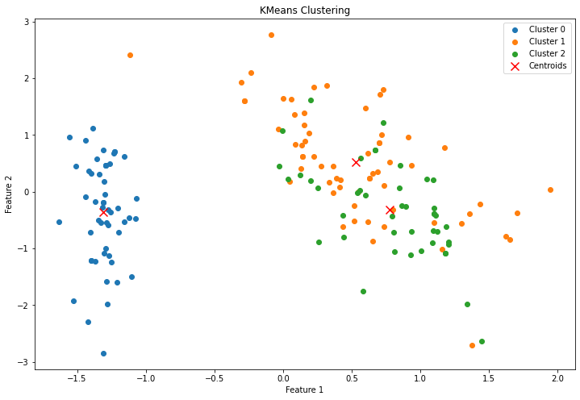

```python
kmeans.plot_clusters(X_train)
```

## K-Nearest Neighbors

Below is an implementation of KNN with gridsearch optimization. In the grid search algorithm, different values of *K* are tested, with the most accurate *K* selected for the most best model cross-validated with the other runs.

```python
import time

class KNN:
    def __init__(self, k):
        self.k = k

    def fit(self, X_train, y_train):
        start = time.time()
        self.X_train = X_train
        self.y_train = y_train
        self.fit_time = time.time() - start

    def validate(self, X_val, y_val):
        start = time.time()
        y_pred = self.predict(X_val)
        accuracy = np.mean(y_pred == y_val)
        self.validate_time = time.time() - start
        return accuracy

    def predict(self, X_test):
        start = time.time()
        distances = np.sqrt(np.sum((self.X_train[:, np.newaxis, :] - X_test) ** 2, axis=2))
        indices = np.argsort(distances, axis=0)[:self.k, :]
        k_closest_classes = self.y_train[indices]
        y_pred = np.apply_along_axis(lambda x: np.bincount(x).argmax(), axis=0, arr=k_closest_classes)
        self.predict_time = time.time() - start
        return y_pred

    def grid_search(X_train, y_train, X_val, y_val, k_range):
        best_params, max_accuracy = None, 0

        for k in k_range:
            knn = KNN(k)
            knn.fit(X_train, y_train)
            accuracy = knn.validate(X_val, y_val)
            if accuracy > max_accuracy:
                max_accuracy = accuracy
                best_params = {'k': k}

        return best_params, max_accuracy

    def visualize_results(self, X_val, y_val, k_range):
        from sklearn.metrics import confusion_matrix, ConfusionMatrixDisplay
        accuracies = []

        for k in k_range:
            knn = KNN(k)
            knn.fit(self.X_train, self.y_train)
            accuracy = knn.validate(X_val, y_val)
            accuracies.append(accuracy)

        # Create a figure and specify the grid
        fig, (ax1, ax2) = plt.subplots(1, 2, figsize=(12, 5))

        # Plot accuracy for different k values
        ax1.plot(k_range, accuracies)
        ax1.set_xlabel('k')
        ax1.set_ylabel('Accuracy')
        ax1.set_title('Accuracy for different k values')

        # Confusion matrix
        y_pred = self.predict(X_val)
        cm = confusion_matrix(y_val, y_pred)
        disp = ConfusionMatrixDisplay(confusion_matrix=cm)
        disp.plot(ax=ax2)
        ax2.set_title('Confusion Matrix')

        # Adjust layout and display plots
        plt.tight_layout()
        plt.show()
```

[figure not shown]

[output not shown]

```python
def encode_categorical_variables(knn_train, knn_valid):
    # Encodes categorical variables using a dictionary.
    cat_dict = dict(enumerate(knn_train['Labels'].astype('category').cat.categories))

    # Reverse the dictionary to get the encodings for the dataframe
    encoding = {value: key for key, value in cat_dict.items()}
    knn_train['Labels'] = knn_train['Labels'].replace(encoding)
    knn_valid['Labels'] = knn_valid['Labels'].replace(encoding)
    return knn_train, knn_valid, cat_dict

def split_feature_matrix_and_labels(knn_train, knn_valid, knn_test):
    # Splits the datasets into feature matrices and label vectors.
    X_train, y_train = knn_train.iloc[:, 1:5].values, knn_train.iloc[:, 5].values
    X_val, y_val = knn_valid.iloc[:, 1:5].values, knn_valid.iloc[:, 5].values
    X_test = knn_test.iloc[:, 1:5].values
    return X_train, y_train, X_val, y_val, X_test

def main():
    # Loads the data, encodes categorical variables, splits the data, performs grid search, fits the best KNN model, and visualizes the results
    # calls the other functions in the proper order, making the code more readable
    knn_valid, knn_test, knn_train = dfs[3], dfs[4], dfs[5]

    knn_train, knn_valid, labels = encode_categorical_variables(knn_train, knn_valid)
    X_train, y_train, X_val, y_val, X_test = split_feature_matrix_and_labels(knn_train, knn_valid, knn_test)

    k_range = [*range(1, 101)]
    best_params, max_accuracy = KNN.grid_search(X_train, y_train, X_val, y_val, k_range)

    knn_best = KNN(best_params['k'])
    knn_best.fit(X_train, y_train)

    # Visualize results
    knn_best.visualize_results(X_val, y_val, k_range)

    y_pred = knn_best.predict(X_test)

    # Test accuracy
    # test_accuracy = np.mean(y_pred == y_test)
    # print(f"Test accuracy: {test_accuracy}")

    knn_test['Labels'] = y_pred
    knn_test['Labels'].replace(labels, inplace = True)

    return knn_test

if __name__ == "__main__":
    start = time.time()
    res = main()
    print(f'Total Execution Time: {time.time()-start}')
```

Predicted label results for the test set

```python
res.to_csv('/content/drive/MyDrive/Computer Science/CSCI436/Homework/Assignment-2/KNN_test_predict.csv', encoding = 'utf-8')
res
```

|  | Id | SepalLengthCm | SepalWidthCm | PetalLengthCm | PetalWidthCm | Labels |
| --- | --- | --- | --- | --- | --- | --- |
| 0 | 1 | 4.6 | 3.2 | 1.4 | 0.20 | Iris-setosa |
| 1 | 2 | 5.3 | 3.7 | 1.5 | 0.20 | Iris-setosa |
| 2 | 3 | 5.0 | 3.3 | 1.4 | 0.22 | Iris-setosa |
| 3 | 4 | 6.2 | 2.9 | 4.3 | 1.30 | Iris-versicolor |
| 4 | 5 | 5.1 | 2.5 | 3.0 | 1.10 | Iris-versicolor |
| 5 | 6 | 5.7 | 2.8 | 4.1 | 1.30 | Iris-versicolor |
| 6 | 7 | 6.5 | 3.0 | 5.2 | 2.00 | Iris-virginica |
| 7 | 8 | 6.2 | 3.4 | 5.4 | 2.30 | Iris-virginica |
| 8 | 9 | 5.9 | 3.0 | 5.1 | 1.80 | Iris-virginica |
| 9 | 10 | 4.5 | 3.1 | 1.3 | 0.30 | Iris-setosa |

# Citations

OpenAI. (2021). ChatGPT (Version GPT-3.5) [Computer software]. OpenAI. https://www.openai.com

OpenAI. (2021). ChatGPT (Version GPT-4) [Computer software]. OpenAI. https://www.openai.com